# Comparing life expectancy in between developing and developed countries

Syed Kabir

1/25/2022

# Introduction

R-pub link: https://rpubs.com/kabir_data_worm/680654

- Life expectancy refers to a measure describing how long a person would like to live.
- Previous studies show that life expectancy varies among the countries worldwide due to different socioeconomic and health factors (Khan, Khan, & Khan, 2010; Lin, Chen, Chien, & Chan, 2012).
- A better understanding of the difference in life expectancy in developing and developed countries is of great importance for international and global development.
- In spite of poor health facilities and lower standard of living and education level; the life expectancy in developing countries was increased 3.6 years per decade compare to 1.8 years per decade in developed countries (United Nations, 2017).
- So it is of great interest to know the present condition of developing and developed countries in terms of life expectancy.

# Problem Statement

- This particular analysis is undertaken to investigate whether the life expectancy in developed countries differs from developing countries or not.
- In order to address this research question, the data on life expectancy of developed and developing countries have been used over a period of five years. Data is collected from Kaggle.
- Initially, descriptive statistics and visualizations on important variables are used to search out the impact of development condition of countries on life expectancy parameter.
- Then, all required assumptions are being checked to carry out appropriate hypothesis test
- Next, Hypothesis testing is used to find out any statistically significant difference in life expectancy in between developed and developing countries.
- Finally, a solid discussion is provided to highlight on limitations, strength, future study and ultimate results of the investigation.

# Data

- Data is collected by clicking on the “Download” tab of the webpage of following link: https://www.kaggle.com/kumarajarshi/life-expectancy-who?select=Life+Expectancy+Data.csv
- The sampling method of the data is not mentioned in data source.
- The “Life Expectancy Data.csv” data-set contains observations for 193 countries covering the time period from 2000-2015 with 22 variables and 2938 observations.
- However this analysis will work on four variables: Country,Year, Status, Life expectancy. The analysis will cover the years from 2011 to 2015.
- “Country” variable is catagorical type representing each country of the world.
- “Status” is nominal type variable with two categories: Developed, Developing. This variable divides country variable as developed and developing countries.
- “Life expectancy” is ratio type. Each value represents average life length of the people of a particular country.

# Data cont.

- At first, importing data from working directory with necessary sub-setting and filtering.
- Checking the attributes of data-frame and class of each variable.

```r
life_expectancy<-read_csv("Life Expectancy Data.csv")%>% select(Country,Year,Status, `Life expectancy`)%>%filter(Year==c(2011:2015))
str(life_expectancy)
```

```
## tibble [185 x 4] (S3: tbl_df/tbl/data.frame)
##  $ Country        : chr [1:185] "Afghanistan" "Albania" "Algeria" "Angola" ...
##  $ Year           : num [1:185] 2013 2011 2014 2012 2015 ...
##  $ Status         : chr [1:185] "Developing" "Developing" "Developing" "Developing" ...
##  $ Life expectancy: num [1:185] 59.9 76.6 75.4 56 76.4 76 73.9 82.7 88 72.7 ...
```

- Changing class of “Status” variable to a factor and defining the levels.

```r
life_expectancy$Status<-factor(life_expectancy$Status,levels=c("Developing","Developed"))
levels(life_expectancy$`Status`)
```

```
## [1] "Developing" "Developed"
```

# Data Cont.(Handling Missing Values)

- Checking missing values: NA, nan, special values. Output is showing 2 NAs in Life expectancy.

```r
is.specialorNA <- function(x){if (is.numeric(x)) (is.infinite(x) | is.nan(x) | is.na(x))}
sapply(life_expectancy, function(y)sum(is.specialorNA(y)))
```

```
##         Country            Year          Status Life expectancy
##               0               0               0               2
```

- Finding location of missing values. Removing 2 missing values as sample size for developing countries is large(153).

```r
life_expectancy[!complete.cases(life_expectancy),]
```

| Country | Year | Status | Life expectancy |
| --- | --- | --- | --- |
| Nauru | 2013 | Developing | NA |
| Saint Kitts and Nevis | 2013 | Developing | NA |

```r
life_expectancy<-life_expectancy%>%na.omit()
```

# Descriptive Statistics and Visualisation

```r
life_expectancy%>%group_by(Status)%>%summarise(Min = min(`Life expectancy`,na.rm = TRUE),Q1 = round(quantile(`Life expectancy`,probs = .25,na.rm = TRUE),2), Median = round(median(`Life expectancy`, na.rm = TRUE),2), Q3 = round(quantile(`Life expectancy`,probs = .75,na.rm = TRUE),2),Max = max(`Life expectancy`,na.rm = TRUE),IQR=IQR(`Life expectancy`,na.rm = TRUE),Mean = round(mean(`Life expectancy`, na.rm = TRUE),2),SD = round(sd(`Life expectancy`, na.rm = TRUE),2), IQR = IQR(`Life expectancy`, na.rm = TRUE), Range= Max-Min,n = n(),Missing = sum(is.na(`Life expectancy`))) -> table1
knitr::kable(table1)
```

| Status | Min | Q1 | Median | Q3 | Max | IQR | Mean | SD | Range | n | Missing |
| --- | --- | --- | --- | --- | --- | --- | --- | --- | --- | --- | --- |
| Developing | 48.1 | 63.15 | 71.0 | 75.05 | 85 | 11.90 | 69.12 | 7.73 | 36.9 | 151 | 0 |
| Developed | 73.4 | 78.47 | 81.4 | 82.53 | 88 | 4.05 | 80.74 | 3.67 | 14.6 | 32 | 0 |

# # Decsriptive Statistics: Boxplot of Life Expectancy

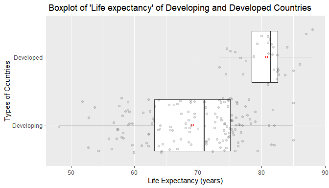

```r
qplot(`Life expectancy`,Status,data=life_expectancy,geom='boxplot')+stat_summary(fun.y=mean,shape=1,col='red',geom='point')+labs(title=" Boxplot of 'Life expectancy' of Developing and Developed Countries", x = "Life Expectancy (years)", y = "Types of Countries")+ geom_jitter(alpha = 1/8)
```

So there is no outlier. Red points represent mean value that differs more than 10 years in between two types of countries.Box-plot shows that life expectancy varies a lot in developing countries compared to developed countries. Developed countries have higher life expectancy than developing countries.

# Decsriptive Statistics Cont.(Visualisation)

- Life expectancy distribution for developing countries is negatively skewed with a fat left tail, right tail is slim.
- Distribution for developed countries is showing characteristics of standard normal distribution relatively more.

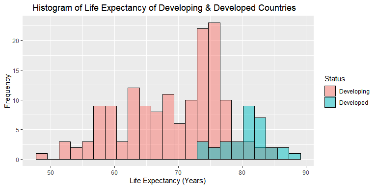

```r
ggplot(life_expectancy , aes(x=`Life expectancy`, fill=Status))+geom_histogram(alpha=0.5,position = 'identity', colour='black',binwidth =1.8 )+ labs(title="    Histogram of Life Expectancy of Developing & Developed Countries",x="Life Expectancy (Years)", y="Frequency")
```

# Visualisation:QQ Plot for Developing Countries

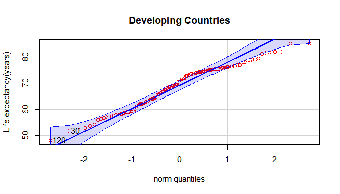

```
## [1] 120  30
```

```r
life_developing<-life_expectancy%>%filter(Status=="Developing")
life_developing$`Life expectancy`%>%car::qqPlot(dist="norm",ylab="Life expectancy(years)",main = "Developing Countries", col = "red")
```